# In-class exercise 7

October 7, 2019

INFO 5871-001

## Imports

```python
import pandas as pd
import numpy as np
%matplotlib inline
import matplotlib.pyplot as plt
import seaborn as sns
import scipy.stats as st
import openpyxl
import re
```

## Load Excel data

Setting `read_only=True` makes it more efficient, because otherwise Python tries to preserve the data in a form that can be written back to Excel. Setting `data_only=True` gives us the data that you see when you look at the spreadsheet, rather than any underlying formulas.

```python
wb = openpyxl.load_workbook('Regional.xlsx', read_only=True, data_only=True)
```

### Get the sheets for the different regions

There are 21 Health Service Regions. Here we extract them using a regular expression.

```python
p = re.compile('HSR \d+')

region_sheets = [name for name in wb.sheetnames if p.match(name)]
region_sheets[0:5]
```

```
['HSR 1', 'HSR 2', 'HSR 3', 'HSR 4', 'HSR 5']
```

### get_entry

A general purpose function to get data from a specific spreadsheet location. We need this because we are picking and choosing individual data elements, rather than whole spreadsheet ranges.

```python
def get_entry(wb, sheetname, row, col):
    """
    Returns the content of a spreadsheet element.

    Arguments:
    wb -- Excel workbook object from openpyxl
    sheetname -- The name of the sheet to extract from
    row, col -- The row and column where the data is to be extracted
    """
    sheet = wb[sheetname]
    cell = f'{col}{row}'
    return sheet[cell].value
```

### Helper function

Gets the data associated with specific years and specific questions. This makes it easier to add new questions if data extraction needs change.

```python
quest_table = {'Uninsured': 15,'Public Ins': 12, 'Doc12': 20, 'Oral Health': 69,
               'Med Cost': 85, 'Doc Cost': 86, 'Mental Health': 72, 'Overall Health': 78}
year_table = {2011: 'E', 2013: 'G', 2015: 'I', 2017: 'K'}

def get_question_value(wb, region, quest, year):
    sheet = wb[region]
    return get_entry(wb, region, quest_table[quest], year_table[year])
```

Example call of the function

```python
get_question_value(wb, 'HSR 1', 'Uninsured', 2013)
```

```
0.1528
```

### Create the data frame

Steps:

- Initialize dictionary that we will use to build the data frame
- Build columns for year and region information
- Add to dictionary
- For each question, extract the question data into a list and add this to the dictionary
- Create a data frame with the dictionary as input

```python
df_dict = {}

region_col = []
year_col = []

for region in region_sheets:
    for year in year_table.keys():
        year_col.append(year)
        region_col.append(region)

df_dict['Region'] = region_col
df_dict['Year'] = year_col

for quest in quest_table.keys():
    quest_col = []
    for region in region_sheets:
        for year in year_table.keys():
            entry = get_question_value(wb, region, quest, year)
            if entry=='NA':
                entry='NaN'
            quest_col.append(entry)

    df_dict[quest] = quest_col

regional_df = pd.DataFrame(df_dict)
```

```python
print (regional_df.shape)
regional_df.head()
```

```
(84, 10)
```

|  | Region | Year | Uninsured | Public Ins | Doc12 | Oral Health | Med Cost | Doc Cost | Mental Health | Overall Health |
| --- | --- | --- | --- | --- | --- | --- | --- | --- | --- | --- |
| 0 | HSR 1 | 2011 | 0.1132 | 0.3667 | 0.7362 | NaN | 0.0962 | 0.0584 | NaN | 0.8295 |
| 1 | HSR 1 | 2013 | 0.1528 | 0.2869 | 0.8212 | 0.7863 | 0.0995 | 0.1338 | 0.9556 | 0.8710 |
| 2 | HSR 1 | 2015 | 0.0559 | 0.4025 | 0.8155 | 0.7851 | 0.1236 | 0.1028 | 0.8879 | 0.7787 |
| 3 | HSR 1 | 2017 | 0.1071 | 0.4570 | 0.7719 | 0.7645 | 0.0876 | 0.0958 | 0.9072 | 0.8149 |
| 4 | HSR 2 | 2011 | 0.1571 | 0.2506 | 0.8104 | NaN | 0.1212 | 0.1218 | NaN | 0.8625 |

Use `describe` to see the overall shape of the data.

```python
regional_df.describe()
```

|  | Year | Uninsured | Public Ins | Doc12 | Med Cost | Doc Cost | Overall Health |
| --- | --- | --- | --- | --- | --- | --- | --- |
| count | 84.000000 | 84.000000 | 84.000000 | 84.000000 | 84.000000 | 84.000000 | 84.000000 |
| mean | 2014.000000 | 0.116502 | 0.324139 | 0.784543 | 0.111189 | 0.117589 | 0.850192 |
| std | 2.249498 | 0.058946 | 0.101659 | 0.050228 | 0.028489 | 0.033997 | 0.041870 |
| min | 2011.000000 | 0.014000 | 0.106900 | 0.669600 | 0.043500 | 0.040800 | 0.739100 |
| 25% | 2012.500000 | 0.072375 | 0.251500 | 0.746825 | 0.093625 | 0.095950 | 0.825500 |
| 50% | 2014.000000 | 0.106500 | 0.310000 | 0.779750 | 0.109900 | 0.116400 | 0.857000 |
| 75% | 2015.500000 | 0.154175 | 0.386525 | 0.823475 | 0.126875 | 0.134875 | 0.876100 |
| max | 2017.000000 | 0.249500 | 0.553900 | 0.903200 | 0.184900 | 0.208000 | 0.945300 |

The different number of columns indicates that some weren't processed as numeric. Correct by explicit casting to `float`.

```python
regional_df['Oral Health'] = regional_df['Oral Health'].astype('float')
regional_df['Mental Health'] = regional_df['Mental Health'].astype('float')
```

Create a MultiIndex with region and year. Rows can now be indexed with the combination of region and year.

```python
sub_df = regional_df.set_index(['Region', 'Year'])
sub_df.head()
```

| Region | Year | Uninsured | Public Ins | Doc12 | Oral Health | Med Cost | Doc Cost | Mental Health | Overall Health |
| --- | --- | --- | --- | --- | --- | --- | --- | --- | --- |
| HSR 1 | 2011 | 0.1132 | 0.3667 | 0.7362 | NaN | 0.0962 | 0.0584 | NaN | 0.8295 |
|  | 2013 | 0.1528 | 0.2869 | 0.8212 | 0.7863 | 0.0995 | 0.1338 | 0.9556 | 0.8710 |
|  | 2015 | 0.0559 | 0.4025 | 0.8155 | 0.7851 | 0.1236 | 0.1028 | 0.8879 | 0.7787 |
|  | 2017 | 0.1071 | 0.4570 | 0.7719 | 0.7645 | 0.0876 | 0.0958 | 0.9072 | 0.8149 |
| HSR 2 | 2011 | 0.1571 | 0.2506 | 0.8104 | NaN | 0.1212 | 0.1218 | NaN | 0.8625 |

Now we're ready to do a `pairplot`.

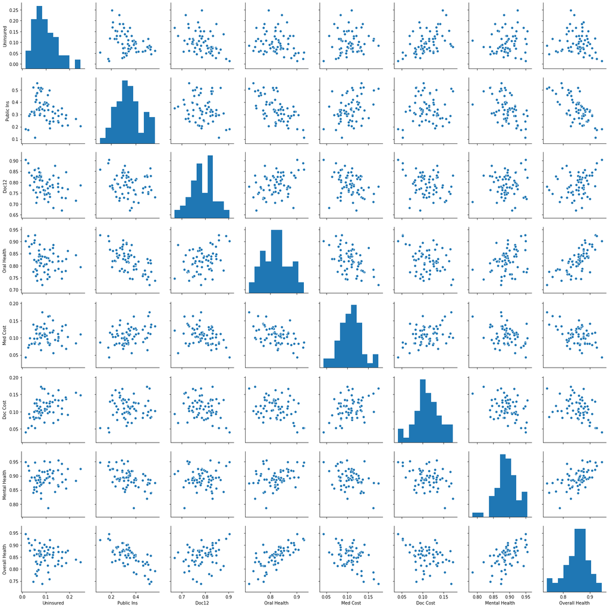

```python
sns.pairplot(sub_df.dropna())
```

What correlations and anti-correlations seem evident?

## Denver metro

Let's pull out just the data for the Denver metro area, which contains regions 17, 21, 3, 16, 20.

```python
regions = [17, 21, 3, 16, 20]
region_names = [f'HSR {r}' for r in regions]
region_names
```

```
['HSR 17', 'HSR 21', 'HSR 3', 'HSR 16', 'HSR 20']
```

Because it is the index, we don't have to do any boolean indexing. We can just supply the region names.

```python
metro_df = sub_df.loc[region_names, :]
print (metro_df.shape)
metro_df
```

```
(20, 8)
```

| Region | Year | Uninsured | Public Ins | Doc12 | Oral Health | Med Cost | Doc Cost | Mental Health | Overall Health |
| --- | --- | --- | --- | --- | --- | --- | --- | --- | --- |
| HSR 3 | 2011 | 0.0727 | 0.1069 | 0.8709 | NaN | 0.1062 | 0.0940 | NaN | 0.9012 |
|  | 2013 | 0.0538 | 0.1107 | 0.8582 | 0.9274 | 0.0869 | 0.0521 | 0.9483 | 0.9209 |
|  | 2015 | 0.0239 | 0.1752 | 0.8875 | 0.9237 | 0.0722 | 0.0522 | 0.9360 | 0.9262 |
|  | 2017 | 0.0140 | 0.1830 | 0.9032 | 0.9021 | 0.0435 | 0.0408 | 0.9496 | 0.9453 |
| HSR 16 | 2011 | 0.0904 | 0.1463 | 0.7746 | NaN | 0.0788 | 0.1160 | NaN | 0.9060 |
|  | 2013 | 0.1177 | 0.1888 | 0.7825 | 0.8679 | 0.1150 | 0.1292 | 0.9217 | 0.9200 |
|  | 2015 | 0.0519 | 0.2964 | 0.8571 | 0.9061 | 0.0834 | 0.1249 | 0.8944 | 0.8809 |
|  | 2017 | 0.0737 | 0.2961 | 0.8310 | 0.8882 | 0.1122 | 0.1340 | 0.8945 | 0.9084 |
| HSR 17 | 2011 | 0.1079 | 0.2986 | 0.8356 | NaN | 0.0951 | 0.1291 | NaN | 0.8690 |
|  | 2013 | 0.1381 | 0.3084 | 0.8768 | 0.7795 | 0.0942 | 0.1346 | 0.8442 | 0.8128 |
|  | 2015 | 0.0571 | 0.4521 | 0.7528 | 0.7563 | 0.1240 | 0.0821 | 0.8845 | 0.8301 |
|  | 2017 | 0.0736 | 0.3966 | 0.8104 | 0.7999 | 0.0844 | 0.0817 | 0.8640 | 0.8544 |
| HSR 20 | 2011 | 0.2089 | 0.3023 | 0.7440 | NaN | 0.1323 | 0.1787 | NaN | 0.8132 |
|  | 2013 | 0.1843 | 0.2664 | 0.7265 | 0.7775 | 0.1369 | 0.1413 | 0.8872 | 0.8689 |
|  | 2015 | 0.0946 | 0.3840 | 0.7628 | 0.8377 | 0.1037 | 0.1081 | 0.8862 | 0.8569 |
|  | 2017 | 0.0895 | 0.3805 | 0.7651 | 0.7975 | 0.1256 | 0.1265 | 0.8770 | 0.8487 |
| HSR 21 | 2011 | 0.1701 | 0.2118 | 0.8332 | NaN | 0.1115 | 0.1230 | NaN | 0.8538 |
|  | 2013 | 0.1159 | 0.2268 | 0.8127 | 0.8204 | 0.0798 | 0.1245 | 0.8980 | 0.8615 |
|  | 2015 | 0.0280 | 0.2877 | 0.8447 | 0.8792 | 0.0789 | 0.0936 | 0.9189 | 0.9085 |
|  | 2017 | 0.0399 | 0.3246 | 0.8303 | 0.8908 | 0.0827 | 0.0589 | 0.8952 | 0.8991 |

## Question 3: Doctor vs Medicine Costs

```python
metro_df['Doc Cost'].mean()
```

```
0.10626500000000001
```

```python
metro_df['Med Cost'].mean()
```

```
0.097365
```

It seems that more people are concerned about the costs of doctors than the cost of medicine. Is this a statistically significant difference?

Assumption: 10,000 households were chosen in Colorado. We will assume these are evenly distributed by regional population. We will also assume that the state officials did a good job and chose people randomly.

- Parameter of interest: difference in proportions $\hat{p_1} - \hat{p_2}$
- H0: The difference is zero. No difference in the groups.
- H1: There is a significant difference
- Significance level 95%, $\alpha$ = 0.05
- $n_1$ = Metro population/Total population * 10,000
- $n_2$ = same because it is the same population
- $SE = \sqrt{\frac{p_1(1-p_1)}{n_1} + \frac{p_2(1-p_2)}{n_2}}$
- $\alpha$ = 0.05
- two-tailed test: if the confidence interval for the difference of means excludes 0, then the two means are significantly different.

Total population of the state in 2017. L8 + L15

```python
total_pop = get_entry(wb, 'HSR 1', 8, 'L') + get_entry(wb, 'HSR 1', 15, 'L')
total_pop
```

```
5390587
```

We are also going to assume that the fraction of the population in different areas didn't change since 2011. Probably unrealistic. J8 + J15

```python
metro_pops = [get_entry(wb, reg, 8, 'J')+get_entry(wb, reg, 15, 'J') for reg in region_names]
metro_total = np.sum(metro_pops)
metro_total
```

```
1994974
```

```python
metro_frac = metro_total / total_pop
metro_frac
```

```
0.37008474216258824
```

```python
n1 = n2 = metro_frac * 10000
```

Bigger and more suspect assumption: we can ignore the size of each area when trying to create an overall mean from individual means. In the homework, we'll do this right.

```python
p1_hat = metro_df['Doc Cost'].mean()
p2_hat = metro_df['Med Cost'].mean()
diff = p1_hat - p2_hat

print (p1_hat)
print (p2_hat)
print (diff)
```

```
0.10626500000000001
0.097365
0.008900000000000019
```

```python
se = np.sqrt((p1_hat*(1-p1_hat)/n1) + (p2_hat*(1-p2_hat)/n2))
se
```

```
0.0070292042472089415
```

```python
(diff - (1.96 * se), diff + (1.96 * se))
```

```
(-0.004877240324529505, 0.022677240324529543)
```

Conclusion

Note that the interval includes zero, so we cannot reject the null hypothesis. These values might be the same.